# Lab 2 Collaboration

Team 21

9/14/2020

### Searching for the Best Chocolates

In our individual work, we analyzed the distribution of chocolate bar ratings and how the number of ratings differ per year. As a group, we then identified a number of variables with possible effects on rating, and thus, overall taste. Therefore, our collaborative effort aims to analyze how the percentage of cacao in a chocolate bar, the origin location of the chocolate, and the combinations of ingredients may affect its rating.

#### Cacao Percentage

To begin, we discovered that the rated chocolate bars had cacao percentages ranging from 42% to 100%. For further analysis, we grouped the percentages into ten-percent ranges from 40 to 100. Meaning, a bar of 54% cacao and a bar of 59% cacao would both be grouped into the 50% range. This data was graphed in a boxplot to visualize the median and general distribution of the data.

```r
choco <- read.csv("https://raw.githubusercontent.com/xdaiISU/ds202materials/master/hwlabs/data/choco.csv")
sort(unique(choco$Cocoa_Percent))
```

```
##  [1]  42.0  46.0  50.0  53.0  55.0  56.0  57.0  58.0  60.0  60.5  61.0  62.0
## [13]  63.0  64.0  65.0  66.0  67.0  68.0  69.0  70.0  71.0  71.5  72.0  72.5
## [25]  73.0  73.5  74.0  75.0  76.0  77.0  78.0  79.0  80.0  81.0  82.0  83.0
## [37]  84.0  85.0  86.0  87.0  88.0  89.0  90.0  91.0  99.0 100.0
```

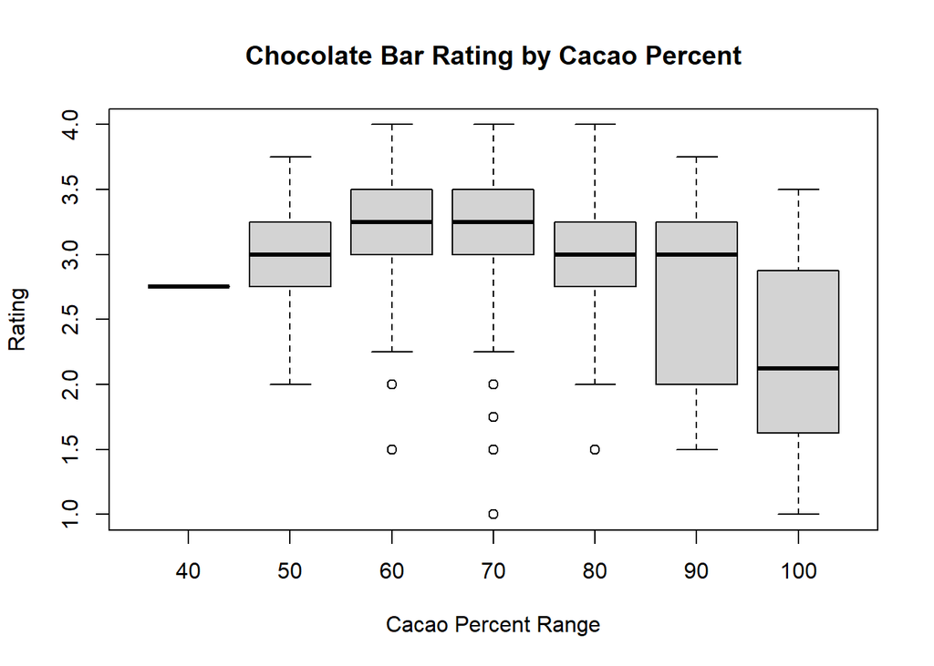

```r
choco$PercentRange <- ((choco$Cocoa_Percent) %/% 10) * 10
plot <- boxplot(choco$Rating ~ choco$PercentRange, xlab = "Cacao Percent Range", main = 'Chocolate Bar Rating by Cacao Percent', ylab = "Rating")
```

```r
M <- tapply(choco$Rating, INDEX = choco$PercentRange, FUN = mean)
print(M)
```

```
##       40       50       60       70       80       90      100
## 2.750000 2.956897 3.211940 3.211089 3.038690 2.730769 2.250000
```

Next, we calculated the mean rating value for each percentage range (shown above). To better visualize this, points were added to the boxplot. This completed figure provides great insight into the relationship between cacao percenteage and overall rating. Chocolate bars in the 60 and 70 percent range had the highest mean and median ratings, and mean score decreased as the percent deviated from this range. Meaning, chocolate bars at 100% cacao had a mean score of 2.25, much lower than the 70% bars at 3.21 (almost a full point difference!). In conclusion, this portion of our analysis suggests a casual relationship between cacao percent and chocolate bar rating - for chocolate bars 70% or higher, as the percent cacao increases, the rating decreases. Thus, cacao percentage does have an effect on taste.

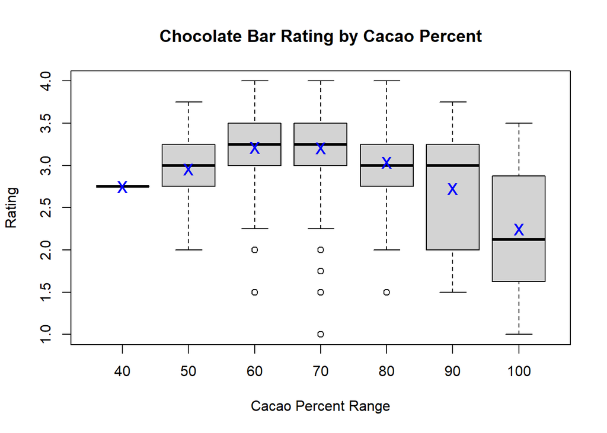

```r
Mplot<- boxplot(choco$Rating ~ choco$PercentRange, xlab = "Cacao Percent Range", main = 'Chocolate Bar Rating by Cacao Percent', ylab = "Rating")
points(M, col = "blue", pch = "x", cex = 1.5)
```

#### Location

To analyze the country of origin and it’s affect on the rating of the chocolate, we first had to create a vector because of the categorical nature of the data. We created a vector for the origin of the bean also created levels from there. After this preparation we were able to create plots for graphical analysis.

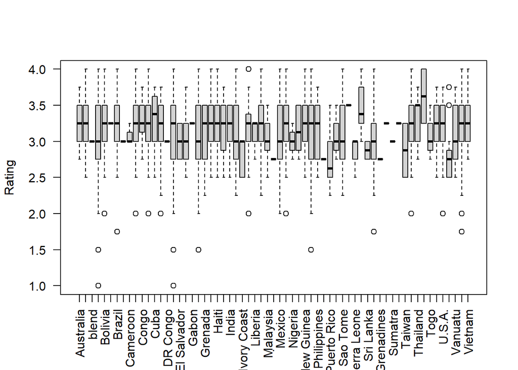

```r
country <- factor(choco$Bean_Origin)
countrylvl <- levels(country)
place <- factor(choco$Bean_Origin, levels = countrylvl)
##First Plot
plot(choco$Rating ~ place, las=2, ylab = "Rating", xlab = ".")
```

```r
length(place) = 20
table(choco$Bean_Origin)
```

```
##
##             Australia                Belize                 blend
##                     3                    67                     1
##                 Blend               Bolivia                Bolvia
##                   151                    72                     1
##                Brazil                 Burma              Cameroon
##                    75                     1                     3
##              Colombia                 Congo            Costa Rica
##                    66                    11                    43
##                  Cuba    Dominican Republic              DR Congo
##                    12                   206                     1
##               Ecuador           El Salvador                  Fiji
##                   212                     6                    15
##                 Gabon                 Ghana               Grenada
##                     1                    37                    19
##             Guatemala                 Haiti              Honduras
##                    53                    24                    23
##                 India             Indonesia           Ivory Coast
##                    21                    18                     5
##               Jamaica               Liberia            Madagascar
##                    23                     3                   163
##              Malaysia            Martinique                Mexico
##                     7                     1                    46
##             Nicaragua               Nigeria                Panama
##                    92                     3                     8
##      Papua New Guinea                  Peru           Philippines
##                    49                   220                    19
##              Principe           Puerto Rico                 Samoa
##                     1                     6                     3
##              Sao Tome   Sao Tome & Principe          Sierra Leone
##                    14                     1                     3
##       Solomon Islands             Sri Lanka             St. Lucia
##                    10                     2                    10
## St.Vincent-Grenadines              Sulawesi               Sumatra
##                     1                     1                     1
##              Suriname                Taiwan              Tanzania
##                     1                     2                    64
##              Thailand                Tobago                  Togo
##                     5                     2                     3
##              Trinidad                U.S.A.                Uganda
##                    38                    30                    11
##               Vanuatu             Venezuela               Vietnam
##                    13                   245                    64
```

```r
worstrating <- choco[order(choco$Rating), ]
worst20 <- head(worstrating, n = 20)
worst20
```

```
##       REF                  Company Location Date Bean_Origin
## 408   141                Callebaut  Belgium 2007     Ecuador
## 544   252          Claudio Corallo Sao Tome 2008       Blend
## 576    48       Cote d' Or (Kraft)  Belgium 2006       Blend
## 1542  135      Neuhaus (Callebaut)  Belgium 2007       Blend
## 284    81                   Bonnat   France 2006       Blend
## 308   341   Bouga Cacao (Tulicorp)  Ecuador 2009     Ecuador
## 407   259  Cacaoyere (Ecuatoriana)  Ecuador 2008     Ecuador
## 573   817                Coppeneur  Germany 2012     Ecuador
## 687    63       Dolfin (Belcolade)  Belgium 2006       Blend
## 1299  721 Machu Picchu Trading Co.     Peru 2011        Peru
## 1460  887               Middlebury   U.S.A. 2012       Blend
## 1848  615                 S.A.I.D.    Italy 2010       Blend
## 1939  693        Snake & Butterfly   U.S.A. 2011       Ghana
## 2189  147                 Valrhona   France 2007       Blend
```

[output cut: 69 more lines]

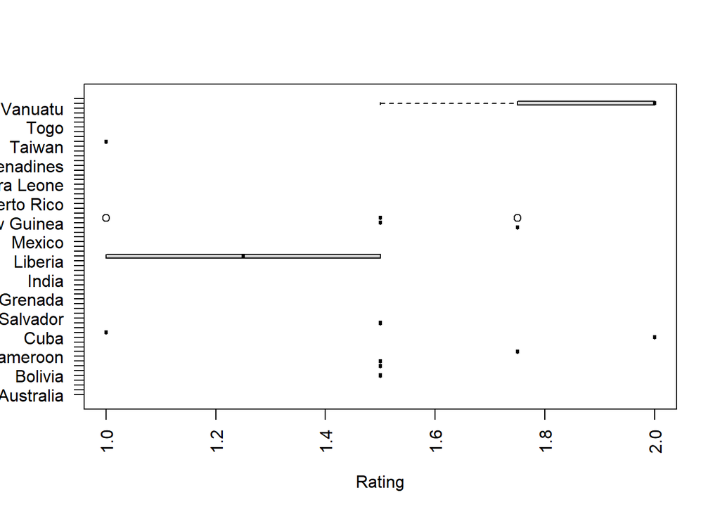

```r
#Worst 20 Ratings plot
plot(worst20$Rating ~ place, horizontal=TRUE, las=2, ylab = "Rating", xlab = ".")
```

```r
bestrating <- choco[order(-choco$Rating), ]
best20 <- head(bestrating, n = 20)
best20
```

```
##      REF             Company    Location Date      Bean_Origin
## 6   1015            A. Morin      France 2013        Venezuela
## 7   1019            A. Morin      France 2013             Peru
## 17  1319            A. Morin      France 2014             Peru
## 73   470               Amano      U.S.A. 2010          Ecuador
## 76   725               Amano      U.S.A. 2011 Papua New Guinea
## 104  572                AMMA      Brazil 2010           Brazil
## 115 1598               Arete      U.S.A. 2015        Nicaragua
## 124 1908               Arete      U.S.A. 2016       Costa Rica
## 125 1924               Arete      U.S.A. 2016             Peru
## 137 2024               Arete      U.S.A. 2017          Bolivia
## 138 2028               Arete      U.S.A. 2017            Haiti
## 143 2254               Arete      U.S.A. 2018         Colombia
## 163  729 Artisan du Chocolat        U.K. 2011            Haiti
## 193 1295     Bar Au Chocolat      U.S.A. 2014             Peru
```

[output cut: 69 more lines]

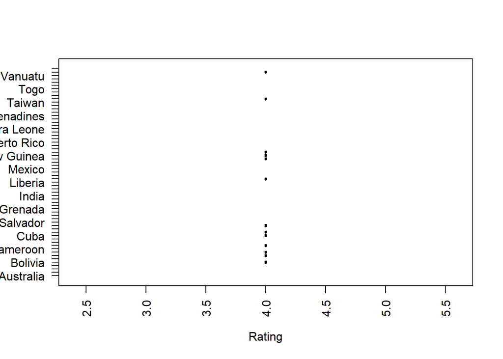

```r
##Best 20 Ratings plot
plot(best20$Rating ~ place, horizontal=TRUE, las=2, ylab = "Rating", xlab = ".")
```

#### Ingredients

Our final analysis is how the combinations of ingredients relate to the overall rating score. Because “ingredients” is a categorical variable consisting of various ingredient combinations, we can make a factor of that data column and extract the levels from that list of factors. We will use that in our boxplot to show the relationship between the the rating and the ingredient combinations. It is very convenient that the names for the ingredients begin with the number of ingredients, because the levels will default to alphabetical order. That will make interpreting the graph easy, without having to re-sort our data.

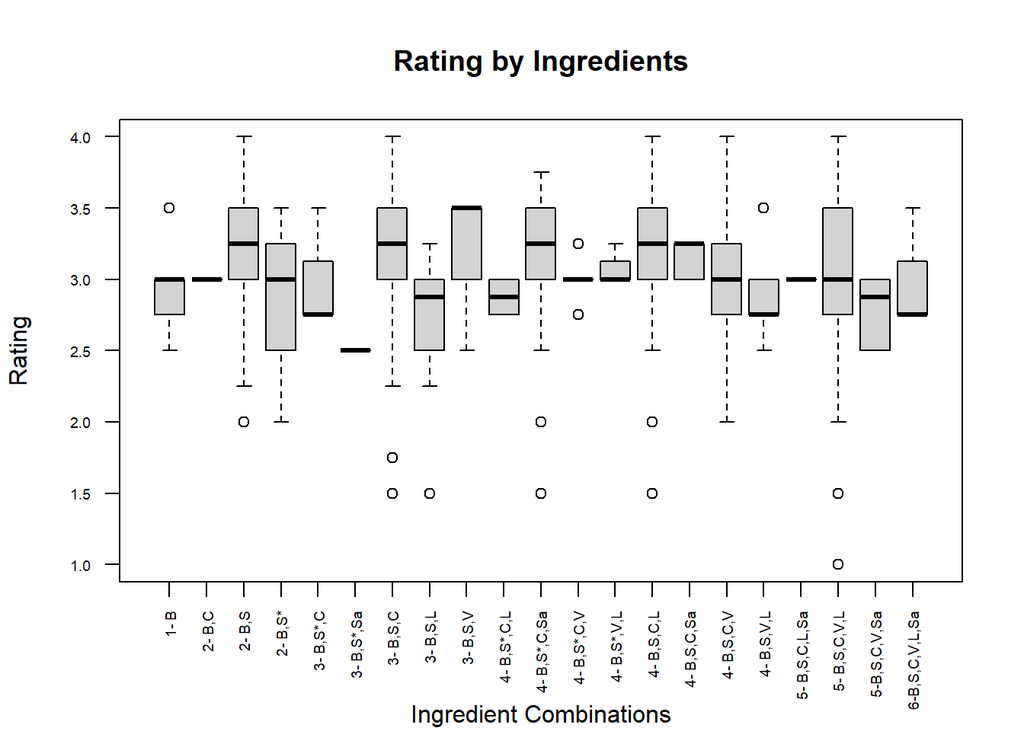

```r
ing_factor = factor(choco$Ingredients)
ing_lvl = levels(ing_factor)
choco_type2 <- factor(choco$Ingredients, levels = ing_lvl)
boxplot(choco$Rating ~ choco_type2, main='Rating by Ingredients', ylab='Rating', xlab='', las=2, cex.axis=.6)
mtext(text= 'Ingredient Combinations', side=1, line=4)   #move the y label down so it doesn't overlap the axis data
```

This shows us which combination of ingredients leads to which rating. For instance, the combination of ingredients with the highest mean rating would be the 3-BSV indicating beans, sugar and vanilla. Another three ingredient combination, Beans, alternative sweetener, and salt had the lowest mean score of around 2.5.